# CSAI3121 - Machine Learning and Intelligent Data Analysis

## Lab 2 - Simple and Multiple Linear Regression (Solution)

In this 1-hour lab, you will use a small subset of the Ames Housing dataset to fit and compare two regression models for predicting `SalePrice`.

**Learning goals**

1. Load and prepare a real tabular dataset.
2. Use exploratory plots and correlations to choose useful predictors.
3. Fit a simple linear regression (SLR) model with one predictor.
4. Fit a multiple linear regression (MLR) model with several predictors.
5. Compare models using R^2, MSE, RMSE, and diagnostic plots.

The features we will use are:

- `Overall Qual`: overall material and finish rating from 1 (very poor) to 10 (excellent)
- `Overall Cond`: overall condition rating from 1 (very poor) to 10 (excellent)
- `Gr Liv Area`: above-ground living area in square feet
- `Central Air`: central air conditioning (N = no, Y = yes)
- `Total Bsmt SF`: total basement area in square feet
- `SalePrice`: sale price in U.S. dollars ($)

This solution notebook follows the same structure as the student worksheet and includes completed code plus suggested responses.

### Step 1. Data Preprocessing (about 10 minutes)

In this section, you will:

- read the dataset
- inspect the first few rows and dimensions
- encode the categorical `Central Air` column
- check for missing values
- remove rows with missing values

```python
import pandas as pd
```

```python
# Read the data.
# We only load the columns needed for this lab.

columns = ['Overall Qual', 'Overall Cond', 'Gr Liv Area', 'Central Air', 'Total Bsmt SF', 'SalePrice']

df = pd.read_csv('AmesHousing.csv', sep='	', usecols=columns)

# Display summary information about the dataset.
df.info()
```

```
<class 'pandas.DataFrame'>
RangeIndex: 2930 entries, 0 to 2929
Data columns (total 6 columns):
 #   Column         Non-Null Count  Dtype
---  ------         --------------  -----
 0   Overall Qual   2930 non-null   int64
 1   Overall Cond   2930 non-null   int64
 2   Total Bsmt SF  2929 non-null   float64
 3   Central Air    2930 non-null   str
 4   Gr Liv Area    2930 non-null   int64
 5   SalePrice      2930 non-null   int64
dtypes: float64(1), int64(4), str(1)
memory usage: 140.3 KB
```

```python
# Display some first few rows of the data

df.head()
```

|  | Overall Qual | Overall Cond | Total Bsmt SF | Central Air | Gr Liv Area | SalePrice |
| --- | --- | --- | --- | --- | --- | --- |
| 0 | 6 | 5 | 1080.0 | Y | 1656 | 215000 |
| 1 | 5 | 6 | 882.0 | Y | 896 | 105000 |
| 2 | 6 | 6 | 1329.0 | Y | 1329 | 172000 |
| 3 | 7 | 5 | 2110.0 | Y | 2110 | 244000 |
| 4 | 5 | 5 | 928.0 | Y | 1629 | 189900 |

```python
# Display the dimensions of the data: (number of rows, number of columns)

df.shape
```

```
(2930, 6)
```

```python
# Convert the string values in Central Air into numeric values.
# N means no central air, Y means yes central air.

df['Central Air'] = df['Central Air'].map({'N': 0, 'Y': 1})
df.head()
```

|  | Overall Qual | Overall Cond | Total Bsmt SF | Central Air | Gr Liv Area | SalePrice |
| --- | --- | --- | --- | --- | --- | --- |
| 0 | 6 | 5 | 1080.0 | 1 | 1656 | 215000 |
| 1 | 5 | 6 | 882.0 | 1 | 896 | 105000 |
| 2 | 6 | 6 | 1329.0 | 1 | 1329 | 172000 |
| 3 | 7 | 5 | 2110.0 | 1 | 2110 | 244000 |
| 4 | 5 | 5 | 928.0 | 1 | 1629 | 189900 |

```python
# Check whether each column has missing values.
df.isnull().sum()
```

```
Overall Qual     0
Overall Cond     0
Total Bsmt SF    1
Central Air      0
Gr Liv Area      0
SalePrice        0
dtype: int64
```

```python
# Remove rows that contain missing values.
# axis=0 means rows are removed.

df = df.dropna(axis=0)
df.isnull().sum()
```

```
Overall Qual     0
Overall Cond     0
Total Bsmt SF    0
Central Air      0
Gr Liv Area      0
SalePrice        0
dtype: int64
```

```python
# Check the new dimensions after removing missing values.
df.shape
```

```
(2929, 6)
```

### Step 2. Data Visualization (about 15 minutes)

Exploratory data analysis (EDA) helps us understand the data before fitting a model.

In this section, you will:

- inspect pairwise relationships between variables
- compute correlations between all numeric variables
- identify candidate predictors for `SalePrice`

If time is short, focus first on the correlation heatmap.

```python
import seaborn as sns
import matplotlib.pyplot as plt

sns.set_style("darkgrid")
```

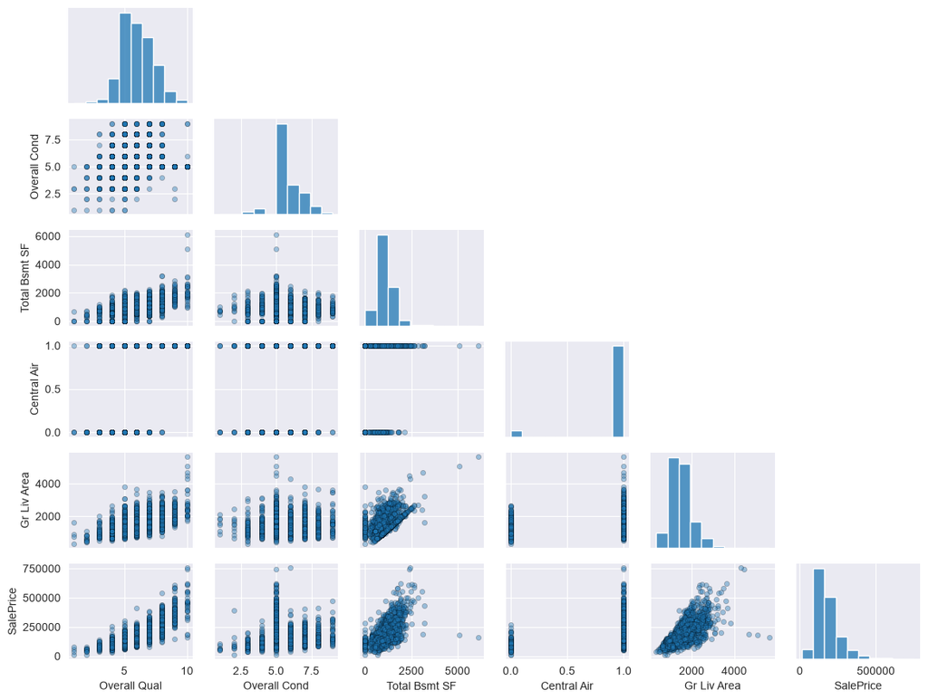

```python
# Optional visual overview: pairwise scatterplots and histograms.
# This can take a few seconds to render.

plt.figure(figsize=(8, 6))

g = sns.PairGrid(df, diag_sharey=False, corner=True, height=1.5, aspect=1.3)
g.map_diag(sns.histplot, bins=10, edgecolor='white')
g.map_lower(sns.scatterplot, s=20, edgecolor='black', alpha=0.4)
plt.show()
```

### Quick Check 1: EDA - Suggested Answer

1. `Overall Qual` has the strongest correlation with `SalePrice` in this selected feature set. `Gr Liv Area` and `Total Bsmt SF` are also strong candidates.
2. There appear to be a few possible outliers, especially houses with very large living area or unusually high sale price.
3. Some predictors are moderately correlated with each other, such as `Overall Qual`, `Gr Liv Area`, and `Total Bsmt SF`. This is useful to notice before fitting MLR.

```python
# Compute the correlation matrix.
# Positive values close to 1 indicate strong positive correlation.
# Negative values close to -1 indicate strong negative correlation.

cm = df.corr()
cm
```

|  | Overall Qual | Overall Cond | Total Bsmt SF | Central Air | Gr Liv Area | SalePrice |
| --- | --- | --- | --- | --- | --- | --- |
| Overall Qual | 1.000000 | -0.094219 | 0.547294 | 0.287443 | 0.570304 | 0.799138 |
| Overall Cond | -0.094219 | 1.000000 | -0.173344 | 0.119611 | -0.115176 | -0.101191 |
| Total Bsmt SF | 0.547294 | -0.173344 | 1.000000 | 0.218726 | 0.444675 | 0.632280 |
| Central Air | 0.287443 | 0.119611 | 0.218726 | 1.000000 | 0.123358 | 0.264700 |
| Gr Liv Area | 0.570304 | -0.115176 | 0.444675 | 0.123358 | 1.000000 | 0.706628 |
| SalePrice | 0.799138 | -0.101191 | 0.632280 | 0.264700 | 0.706628 | 1.000000 |

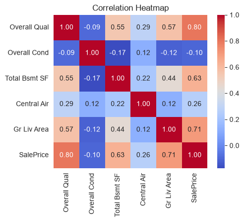

```python
plt.figure(figsize=(5, 4))
sns.heatmap(cm, annot=True, cmap='coolwarm', fmt='.2f')
plt.title('Correlation Heatmap')
plt.show()

# Other available colormaps: rocket, mako, viridis, plasma, coolwarm
```

#### Think Before Modeling - Suggested Answer

Based on the correlation heatmap, `Overall Qual` is the strongest single predictor of `SalePrice` among these variables.

For this lab, we start the simple linear regression with `Gr Liv Area` because its slope has a very concrete interpretation: the expected change in sale price for one additional square foot of above-ground living area.

### Step 3. Simple Linear Regression (SLR) (about 15 minutes)

We will first fit a model with one predictor:

`SalePrice = intercept + slope * Gr Liv Area`

`statsmodels` is useful here because it gives a detailed regression summary, including coefficients, R^2 values, and p-values.

```python
import statsmodels.api as sm

x = df[['Gr Liv Area']]
y = df['SalePrice']

# Add the intercept term.
x1 = sm.add_constant(x)

# Create and fit the OLS regression model.
olsm = sm.OLS(y, x1)
model = olsm.fit()

# View the fitted coefficients.
model.params
```

```
const          13342.978662
Gr Liv Area      111.666258
dtype: float64
```

```python
# A more comprehensive analysis result can be found in the summary.
model.summary()
```

OLS Regression Results

| Dep. Variable: | SalePrice | R-squared: | 0.499 |
| --- | --- | --- | --- |
| Model: | OLS | Adj. R-squared: | 0.499 |
| Method: | Least Squares | F-statistic: | 2919. |
| Date: | Sat, 05 Sep 2026 | Prob (F-statistic): | 0.00 |
| Time: | 19:03:20 | Log-Likelihood: | -36206. |
| No. Observations: | 2929 | AIC: | 7.242e+04 |
| Df Residuals: | 2927 | BIC: | 7.243e+04 |
| Df Model: | 1 |  |  |
| Covariance Type: | nonrobust |  |  |

|  | coef | std err | t | P>\|t\| | [0.025 | 0.975] |
| --- | --- | --- | --- | --- | --- | --- |
| const | 1.334e+04 | 3271.231 | 4.079 | 0.000 | 6928.832 | 1.98e+04 |
| Gr Liv Area | 111.6663 | 2.067 | 54.029 | 0.000 | 107.614 | 115.719 |

| Omnibus: | 491.815 | Durbin-Watson: | 1.068 |
| --- | --- | --- | --- |
| Prob(Omnibus): | 0.000 | Jarque-Bera (JB): | 5129.097 |
| Skew: | 0.468 | Prob(JB): | 0.00 |
| Kurtosis: | 9.415 | Cond. No. | 4.96e+03 |

Notes:  
[1] Standard Errors assume that the covariance matrix of the errors is correctly specified.  
[2] The condition number is large, 4.96e+03. This might indicate that there are  
strong multicollinearity or other numerical problems.

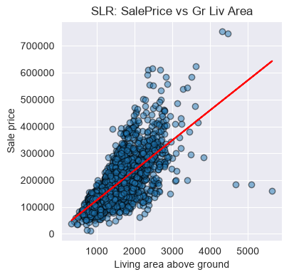

```python
from sklearn.metrics import r2_score, mean_squared_error

# Generate the predicted SalePrice values.
y_pred = model.predict(x1)

plt.figure(figsize=(4, 4))
plt.scatter(x, y, edgecolor='black', alpha=0.5)
plt.plot(x, y_pred, color='red')
plt.xlabel('Living area above ground')
plt.ylabel('Sale price')
plt.title('SLR: SalePrice vs Gr Liv Area')
plt.show()
```

```python
# Compute SLR evaluation metrics.

slr_r2 = r2_score(y, y_pred)
slr_mse = mean_squared_error(y, y_pred)
slr_rmse = slr_mse ** 0.5

print(f'SLR R^2: {slr_r2:.4f}')
print(f'SLR MSE: {slr_mse:.2f}')
print(f'SLR RMSE: ${slr_rmse:,.2f}')
```

```
SLR R^2: 0.4993
SLR MSE: 3193487567.35
SLR RMSE: $56,510.95
```

### Quick Check 2: Interpret the SLR Model - Suggested Answer

1. The slope for `Gr Liv Area` is about 111.67, so the fitted model predicts roughly $112 more in sale price for each additional square foot of above-ground living area.
2. No. The SLR R^2 is about 0.4993, meaning the model explains about 49.9% of the in-sample variation in `SalePrice`.
3. Yes. RMSE is easier to interpret because it is measured in dollars, while MSE is measured in squared dollars.

### Step 4. Multiple Linear Regression (MLR) (about 15 minutes)

Now fit a model using all available predictors except `SalePrice`.

Your task: modify the SLR pattern above to build the MLR model, print the summary, and compare the result with the SLR model.

```python
multi_x = df.drop(columns=['SalePrice'])
y = df['SalePrice']

multi_x1 = sm.add_constant(multi_x)

# Create and fit the OLS regression model.
mlr = sm.OLS(y, multi_x1)
model_mlr = mlr.fit()

# Display the model summary.
model_mlr.summary()
```

OLS Regression Results

| Dep. Variable: | SalePrice | R-squared: | 0.765 |
| --- | --- | --- | --- |
| Model: | OLS | Adj. R-squared: | 0.765 |
| Method: | Least Squares | F-statistic: | 1902. |
| Date: | Sat, 05 Sep 2026 | Prob (F-statistic): | 0.00 |
| Time: | 19:03:23 | Log-Likelihood: | -35098. |
| No. Observations: | 2929 | AIC: | 7.021e+04 |
| Df Residuals: | 2923 | BIC: | 7.024e+04 |
| Df Model: | 5 |  |  |
| Covariance Type: | nonrobust |  |  |

|  | coef | std err | t | P>\|t\| | [0.025 | 0.975] |
| --- | --- | --- | --- | --- | --- | --- |
| const | -1.227e+05 | 5255.225 | -23.340 | 0.000 | -1.33e+05 | -1.12e+05 |
| Overall Qual | 2.733e+04 | 690.226 | 39.597 | 0.000 | 2.6e+04 | 2.87e+04 |
| Overall Cond | 1120.1039 | 664.256 | 1.686 | 0.092 | -182.354 | 2422.562 |
| Total Bsmt SF | 38.9346 | 2.010 | 19.369 | 0.000 | 34.993 | 42.876 |
| Central Air | 1.151e+04 | 3049.849 | 3.774 | 0.000 | 5529.764 | 1.75e+04 |
| Gr Liv Area | 52.6545 | 1.763 | 29.858 | 0.000 | 49.197 | 56.112 |

| Omnibus: | 1029.485 | Durbin-Watson: | 1.465 |
| --- | --- | --- | --- |
| Prob(Omnibus): | 0.000 | Jarque-Bera (JB): | 81574.117 |
| Skew: | -0.757 | Prob(JB): | 0.00 |
| Kurtosis: | 28.809 | Cond. No. | 1.43e+04 |

Notes:  
[1] Standard Errors assume that the covariance matrix of the errors is correctly specified.  
[2] The condition number is large, 1.43e+04. This might indicate that there are  
strong multicollinearity or other numerical problems.

```python
# Generate the predicted SalePrice values for the MLR model.
mlr_y_pred = model_mlr.predict(multi_x1)

# Compute MLR evaluation metrics.
mlr_r2 = r2_score(y, mlr_y_pred)
mlr_mse = mean_squared_error(y, mlr_y_pred)
mlr_rmse = mlr_mse ** 0.5

print(f'MLR R^2: {mlr_r2:.4f}')
print(f'MLR MSE: {mlr_mse:.2f}')
print(f'MLR RMSE: ${mlr_rmse:,.2f}')
```

```
MLR R^2: 0.7649
MLR MSE: 1499345498.08
MLR RMSE: $38,721.38
```

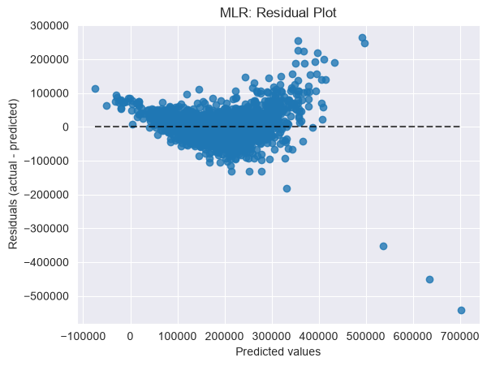

```python
# Diagnostic plot: residual plot.

from sklearn.metrics import PredictionErrorDisplay

display = PredictionErrorDisplay(y_true=y, y_pred=mlr_y_pred)
display.plot()
plt.title('MLR: Residual Plot')
plt.show()
```

### Step 5. Reflection / Exit Ticket - Suggested Answer

1. Yes, the MLR model is better on these in-sample metrics. R^2 improves from about 0.4993 to 0.7649, and RMSE decreases from about $56,510.95 to about $38,721.38.
2. `Overall Qual` has very strong evidence of being useful: it has a very small p-value and a large positive coefficient. `Gr Liv Area` and `Total Bsmt SF` also have very small p-values.
3. The residual plot should show many points near 0, but the pattern is not perfect. Some expensive or unusual houses are still poorly predicted, suggesting outliers or nonlinear relationships.
4. The model could be improved by adding more relevant house features, checking train/test performance, transforming `SalePrice`, adding interaction terms, or trying nonlinear models in a future lab.

```python
# Optional extension solution:
# Remove Overall Cond, which has the weakest evidence in the full MLR summary.
# This simplifies the model, although the in-sample R^2 and RMSE are almost unchanged.

simplified_x = df.drop(columns=['SalePrice', 'Overall Cond'])
y = df['SalePrice']

simplified_x1 = sm.add_constant(simplified_x)
simplified_mlr = sm.OLS(y, simplified_x1)
simplified_model = simplified_mlr.fit()

simplified_y_pred = simplified_model.predict(simplified_x1)
simplified_r2 = r2_score(y, simplified_y_pred)
simplified_mse = mean_squared_error(y, simplified_y_pred)
simplified_rmse = simplified_mse ** 0.5

print(f'Full MLR R^2: {mlr_r2:.4f}')
print(f'Simplified MLR R^2: {simplified_r2:.4f}')
print(f'Full MLR RMSE: ${mlr_rmse:,.2f}')
print(f'Simplified MLR RMSE: ${simplified_rmse:,.2f}')

simplified_model.summary()
```

```
Full MLR R^2: 0.7649
Simplified MLR R^2: 0.7647
Full MLR RMSE: $38,721.38
Simplified MLR RMSE: $38,740.21
```

OLS Regression Results

| Dep. Variable: | SalePrice | R-squared: | 0.765 |
| --- | --- | --- | --- |
| Model: | OLS | Adj. R-squared: | 0.764 |
| Method: | Least Squares | F-statistic: | 2376. |
| Date: | Sat, 05 Sep 2026 | Prob (F-statistic): | 0.00 |
| Time: | 19:03:26 | Log-Likelihood: | -35100. |
| No. Observations: | 2929 | AIC: | 7.021e+04 |
| Df Residuals: | 2924 | BIC: | 7.024e+04 |
| Df Model: | 4 |  |  |
| Covariance Type: | nonrobust |  |  |

|  | coef | std err | t | P>\|t\| | [0.025 | 0.975] |
| --- | --- | --- | --- | --- | --- | --- |
| const | -1.164e+05 | 3730.380 | -31.207 | 0.000 | -1.24e+05 | -1.09e+05 |
| Overall Qual | 2.731e+04 | 690.376 | 39.564 | 0.000 | 2.6e+04 | 2.87e+04 |
| Total Bsmt SF | 38.4256 | 1.988 | 19.329 | 0.000 | 34.528 | 42.324 |
| Central Air | 1.236e+04 | 3009.192 | 4.106 | 0.000 | 6456.058 | 1.83e+04 |
| Gr Liv Area | 52.5426 | 1.763 | 29.806 | 0.000 | 49.086 | 55.999 |

| Omnibus: | 1017.206 | Durbin-Watson: | 1.469 |
| --- | --- | --- | --- |
| Prob(Omnibus): | 0.000 | Jarque-Bera (JB): | 79229.630 |
| Skew: | -0.740 | Prob(JB): | 0.00 |
| Kurtosis: | 28.436 | Cond. No. | 1.13e+04 |

Notes:  
[1] Standard Errors assume that the covariance matrix of the errors is correctly specified.  
[2] The condition number is large, 1.13e+04. This might indicate that there are  
strong multicollinearity or other numerical problems.